# UML Class Diagrams

Ayeshma Nanayakkara

Department of Computer Engineering, Faculty of Engineering University of Sri Jayewardenepura

## Purpose of Class Diagrams

1. Shows static structure of classifiers in a system
2. Diagram provides a basic notation for other structure diagrams prescribed by UML
3. Helpful for developers and other team members too
4. Business Analysts can use class diagrams to model systems from a business perspective

A UML class diagram is made up of:

- A set of classes and
- A set of relationships between classes

## What is a Class

A description of a group of objects all with similar roles in the system, which consists of:

- **Structural features** (attributes) define what objects of the class “know”
  - Represent the state of an object of the class
  - Are descriptions of the structural or static features of a class
- **Behavioral features** (operations) define what objects of the class “can do”
  - Define the way in which objects may interact
  - Operations are descriptions of behavioral or dynamic features of a class

## Class Notation

**Class Name**

**Class Attributes**

- Attributes are shown in the second partition. - The attribute type is shown after the colon. - Attributes map onto member variables (data members) in code.

**Class Operations (Methods)**

- Operations are shown in the third partition. They are services the class provides.
- The return type of a method is shown after the colon at the end of the method signature.
- The return type of method parameters is shown after the colon following the parameter name.
- Operations map onto class methods in code

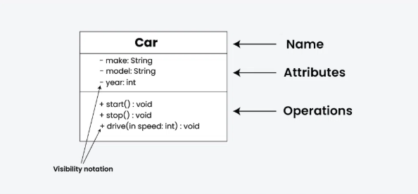

## Class Relationships

A class may be involved in one or more relationships with other classes.

**Inheritance (or Generalization)**

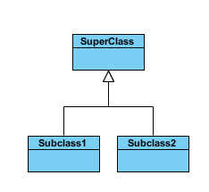

- Represents an “is-a” relationship.
- An abstract class name is shown in italics.
- SubClass1 and SubClass2 are specializations of Super Class.
- A solid line with a hollow arrowhead that point from the child to the parent class

**Simple Association**

**Aggregation**

A special type of association. It represents a “part of” relationship.

**Composition**

A special type of aggregation where parts are destroyed when the whole is destroyed.

**Dependency**

### Relationship Names

- Names of relationships are written in the middle of the association line.

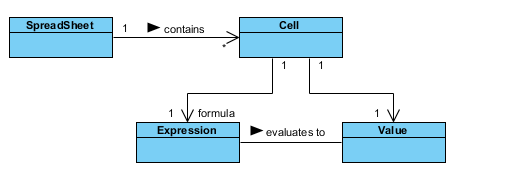

## Visibility of Class attributes and Operations

In object-oriented design, there is a notation of visibility for attributes and operations. UML identifies four types of visibility: **public**, **protected**, **private**, and **package**.

The +, -, # and ~ symbols before an attribute and operation name in a class denote the visibility of the attribute and operation.

## Multiplicity

How many objects of each class take part in the relationships and multiplicity can be expressed as:

- Exactly one - 1
- Zero or one - 0..1
- Many - 0..* or *
- One or more - 1..*

## Practice Question 1

A food delivery app with Customer, Order, Restaurant, DeliveryPerson

## Practice Question 2

Create a UML Class diagram which shows a domain model for online shopping. The purpose of the diagram is to introduce some common terms for online shopping - Customer, Web User, Account, Shopping Cart, Product, Order, Payment, etc. and relationships between. It could be used as a common groundbetween business analysts and software developers. Each customer has unique id and is linked to exactly one account. Account owns shopping cart and orders. Customer could register as a web user to be able tobuy items online. Customer is not required to be a web user because purchases could also be made by phone or by ordering from catalogue. Web user has loginname which also serves as unique id. Web user could be in several states - new, active, temporary blocked, or banned, and be linked to a shopping cart. Shoppingcart belongs to account. Account owns customer orders. Customer may have no orders. Customer orders are sorted and unique. Each order could refer to several payments, possibly none. Every payment has unique id and is related to exactly one account. Each order has current order status. Both order and shopping cart have line items linked to a specific product. Each line item is related to exactly one product. A product could be associated to many line items or no item at all.